# Data Visualization and Mixed Models

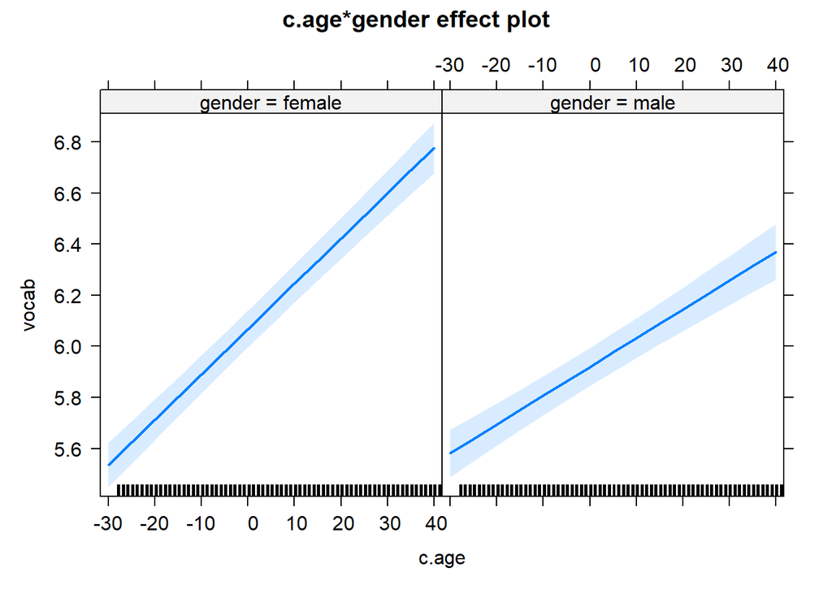

Indeed, we can see that the relationship between age and vocabulary scores is weaker (=smaller slope) for males.

```
## NOTE: c.age:nativeBorn is not a high-order term in the model
```

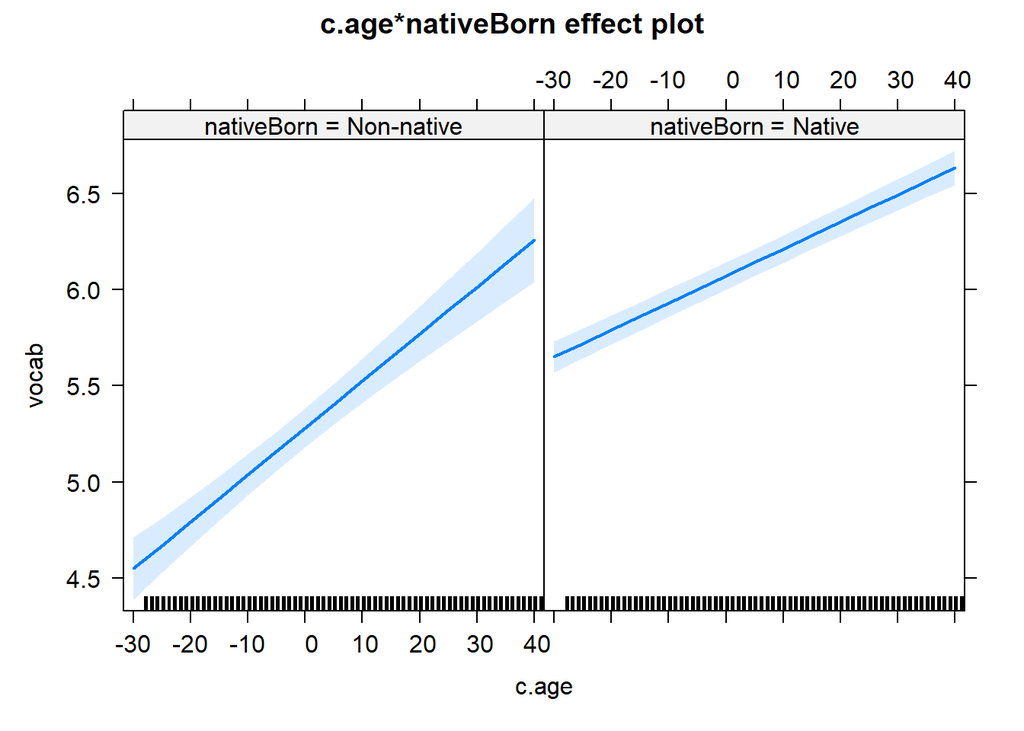

It might be useful to plot these slopes from the model on top on the raw data. This is very easy to do in ggplot: we can combine data from different files together.

```
## NOTE: c.age:nativeBorn is not a high-order term in the model
```

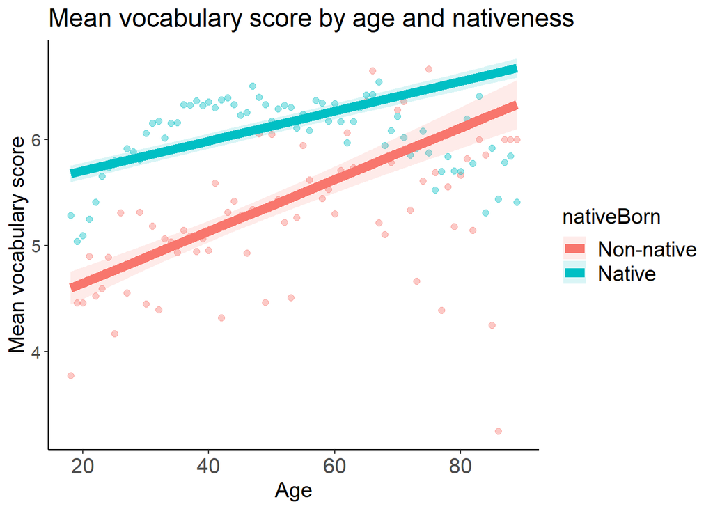

Great! We see that except for the fact that natives have higher scores, nativeness is changing the relationship between age and vocabulary scores (i.e., the slope is steeper for non-natives).

### Plotting (and understanding) triple interactions

```
## NOTE: c.age:nativeBorn:gender is not a high-order term in the model
```

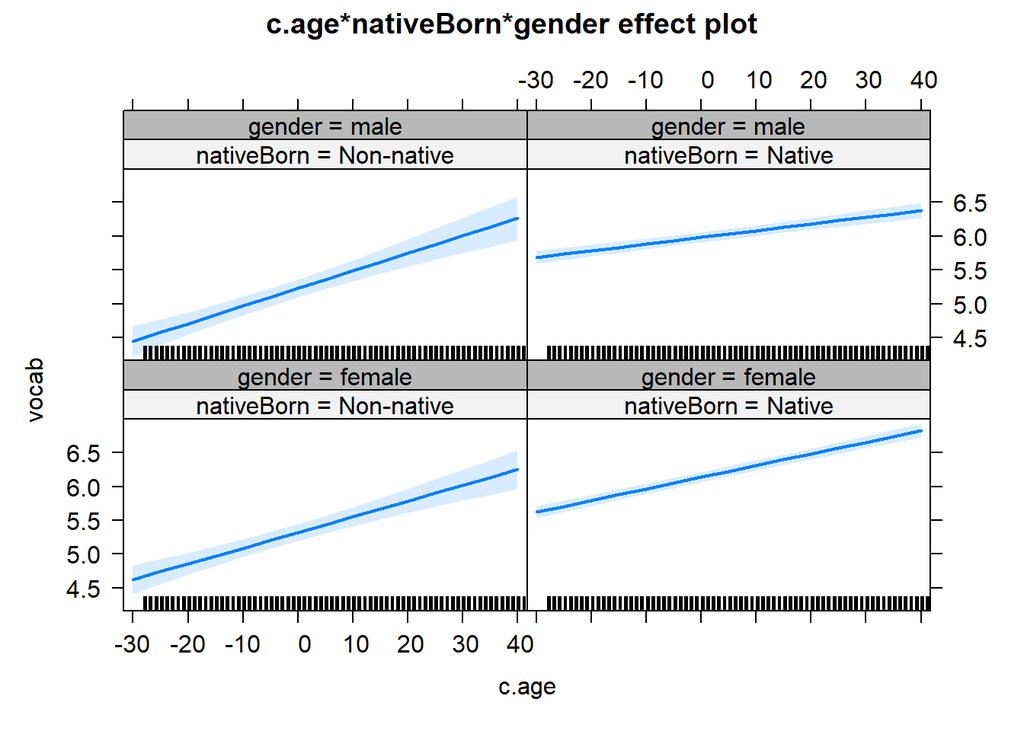

This plot is actually not so clear and it’s hard to see the differences, but the idea is that the significant relationship between age and gender (i.e., males showing a weaker relationship) is somewhat modulated by nativeness (so it is true only for the natives).

Maybe we can try to plot the model AND the raw data together to get a better picture.

```
## NOTE: c.age:nativeBorn:gender is not a high-order term in the model
```

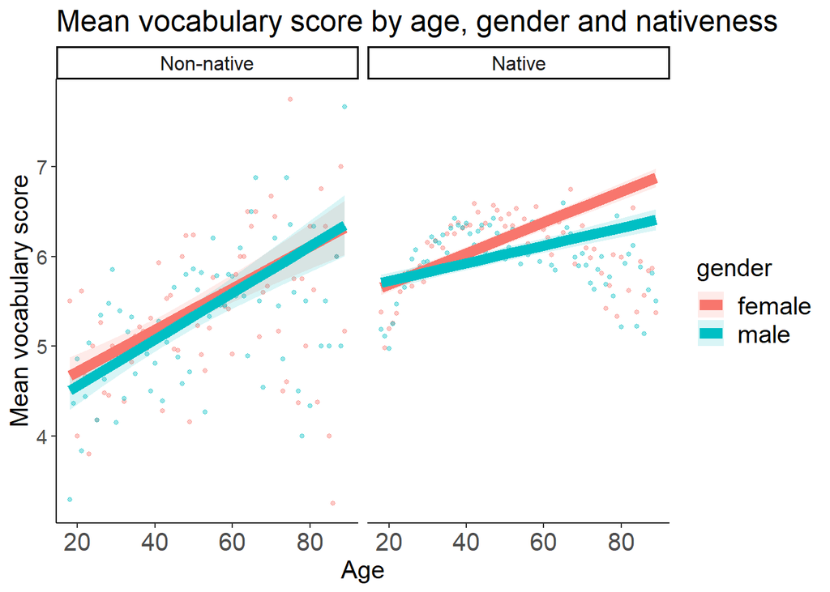

### Time to do some model plotting yourself! :)

1. Creat a new r code chunk, and give it a useful name
2. Plot the interaction between nativeness and gender
3. Plot the interaction between nativeness and education
4. Plot the interaction between gender and education
5. Plot the triple interaction between gender, education and nativeness
6. Plot the raw data + model estimates for one of the interactions above
7. Check: do the plots fit the model’s output and the significance of the interactions?

## Side note about contrasts for categorical variables:

The “basic” coding schemes are: - *Dummy coding* = compares levels to a baseline level (this is done with 0’s and 1’s) - *Sum/deviation coding* = compares levels to the grand mean (this is done with -1’s and 1’s)

There are *many* other coding schemes to make many more comparisons (even user-defined ones). You can check out this webpage for useful examples and coding matrices: https://stats.idre.ucla.edu/r/library/r-library-contrast-coding-systems-for-categorical-variables/

Using different coding schemes asks different questions, and makes different comparisons. It will therefore yield different coefficients (estimates). *But the overall model fit stays the same, and **the significance of the predictor remains the same**!!*

If you want to be sure, let’s rerun the same model after changing the contrasts of “nativeBorn” to c(-1,1) and check for yourself!

Original model

|  | Estimate | Std.Error | t-value |
| --- | --- | --- | --- |
| (Intercept) | 6.136804 | 0.037227 | 164.849634 |
| Age | 0.017200 | 0.000882 | 19.509072 |
| Years of Education | 0.367218 | 0.005759 | 63.758943 |
| Nativeness (Non-native vs. Native) | -0.816024 | 0.053398 | -15.281901 |
| Gender (Male vs. Female) | -0.153512 | 0.023258 | -6.600402 |
| Age X Education | 0.000674 | 0.000308 | 2.188081 |
| Age X Nativeness | 0.006001 | 0.003292 | 1.822971 |
| Education X Nativeness | -0.109928 | 0.014383 | -7.643080 |
| Age X Gender | -0.007321 | 0.001356 | -5.399183 |
| Education X Gender | 0.009234 | 0.008303 | 1.112089 |
| Nativeness X Gender | 0.061978 | 0.079648 | 0.778152 |
| Age X Education X Nativeness | -0.000824 | 0.000885 | -0.930911 |
| Age X Education X Gender | -0.001659 | 0.000456 | -3.634637 |
| Age X Nativeness X Gender | 0.010065 | 0.004912 | 2.049208 |
| Education X Nativeness X Gender | -0.032333 | 0.020611 | -1.568752 |
| Age X Education X Nativeness X Gender | -0.000347 | 0.001251 | -0.277588 |

Model with sum-coding

|  | Estimate | Std.Error | t-value | p-value |
| --- | --- | --- | --- | --- |
| (Intercept) | 5.726930 | 0.043339 | 132.144121 | 0.000000 |
| Age | 0.020071 | 0.001612 | 12.450813 | 0.000000 |
| Nativeness (Non-native vs. Native) | -0.404644 | 0.026574 | -15.226986 | 0.000000 |
| Gender (Male vs. Female) | -0.109305 | 0.039611 | -2.759472 | 0.005789 |
| Years of Education | 0.313824 | 0.007114 | 44.115960 | 0.000000 |
| Age X Nativeness | 0.003249 | 0.001612 | 2.016057 | 0.043794 |
| Age X Gender | -0.001369 | 0.002421 | -0.565363 | 0.571827 |
| Nativeness X Gender | 0.033217 | 0.039613 | 0.838532 | 0.401732 |
| Nativeness X Education | -0.056832 | 0.007103 | -8.001045 | 0.000000 |
| Education X Gender | -0.011800 | 0.010206 | -1.156118 | 0.247633 |
| Age X Nativeness X Gender | 0.005264 | 0.002421 | 2.174262 | 0.029686 |
| Education X Nativeness X Gender | -0.012553 | 0.010203 | -1.230326 | 0.218575 |